# Analysis_on__Remote_Working_Survey__Data_Updated

## **Project: Analysis on the 'REMOTE WORKING SURVEY' Dataset**

## Objective of this Analysis:

The COVID-19 panedemic has introduced a new dimension of working environment for professionals working in all industry. This change is mostly evident among the people who sit in front of the computer most of the time, have professional meetings in the working hours and might not have to engage into heavy physical labour in their workplace.

This practice has changed people's daily working habit. In terms of pros and cons, I tried to analyse these factors from both of the employees and the employer's point-of-view.

With the upcoming Financial uncertainity; factors like Recession, Recruitment, Team Management, Promotions- etc are some of the factors that the Employers have to keep mind in while planning for the future ahead.

## Understand the Data:

### Access and Explore Data:

I found the data set [here](https://www.mavenanalytics.io/data-playground). As it is mentioned here that- "Survey results of 1,500 remote workers from the Australian state of New South Wales, taken in August-September 2020 and March-April 2021, which aimed to capture the shift in remote work experiences and attitudes during different stages of the COVID-19 pandemic and gain insights on its long term implications."

The record has 2 datasets which are surveys conducted on 2020 and 2021. I considered 2021 to be the recent Data that will more relevant in the context with 2022.

As mentioned in the @MavenAnalytics Website, the Recommended Analysis can be the questions as-

- How has the COVID pandemic impacted the amount of work done remotely? What can be expected post-pandemic?
- Does working remotely positively impact productivity? Are there any other benefits?
- How does an employees use of time differ when working remotely vs on-site?
- What are the biggest barriers to overcome if remote work becomes the norm in the future?

We will try to find out answers to these questions.

## Data Processing:

### Data Manipulation, Cleaning and Defining:

The Dataset is the record of surveys conducted on 2020 and 2021. I considered the 2021 data.

- The 2021 Dataset had 81 Columns. The header of the dataset had the Questions asked to the participants, which was diffcult to read and write during programing. So, I renamed all the columns. The details on the variable definition can be found [here](https://github.com/myasmin/Remote-Working-Survey/blob/main/Defining%20Variables.csv).
- A column named AGE was inserted in the context of calculating the age of the participants in 2021.
- The cleaned and processed dataset can be found [here](https://github.com/myasmin/Remote-Working-Survey/blob/main/2021_Employee%20and%20Manager%20Data.csv).
- There wasn't any missing data, but the participants who worked in Managerial posts had some questions answered and the rest were left blank. I took the subset of those participants to remove the blank cells and named it as- [2021_Managers Survey](https://github.com/myasmin/Remote-Working-Survey/blob/main/2021_Managers_Survey.csv).
- For further analysis, I figured out that the barriers for remote work in 2020 would be required. I subsetted the data of 2020 to find the factors that were barriers for the employees, and named it [2020_Barriers_Data](https://github.com/myasmin/Remote-Working-Survey/blob/main/2020_Barriers_Data.csv).

## Analysis of the "Remote-Working-Survey" Dataset:

We will try to make some interpretation throughout this analysis with Charts and Tables from the Datasets mentioned above for analysis, using Python.

- Erase everything in record to avoid overlapping, if any-

```python
%reset -f
```

- Mount the Google Drive to access the Datasets-

```python
from google.colab import drive
drive.mount('/content/gdrive')
```

- Import the necessary Libraires-

```python
import numpy as np
import pandas as pd
import matplotlib.pyplot as plt
import seaborn as sns
import warnings
```

- Supress Warnings-

```python
warnings.filterwarnings("ignore")
```

- Import the Datasets-

```python
manager = pd.read_csv('gdrive/My Drive/Projects/Write a blog post/2021_Managers_Survey.csv')
employee = pd.read_csv('gdrive/My Drive/Projects/Write a blog post/2021_Employee and Manager Data.csv')
barrier = pd.read_csv('gdrive/My Drive/Projects/Write a blog post/2020_Barriers_Data.csv')
```

- Check the Dataset-

```python
employee.head()
# manager.head()
# barrier.head()
```

|  | ID | Year of Birth | Age | Gender | Employment Duration | Industry | Occupation | Size of Employer Company | Size of Household | Residency Area | ... | Opinion on Remote Employee Retention | Opinion on Remote Employee Recruitment | Opinion on Remote Team Work | Opinion on monitoring Remote Team | Opinion on Remote Poor Performers | Opinion on Preparation for Remote Employee Management | Opinion on Preparation for Focus on Work | Opinion on Finding Employees | Manager's Productivity on Remote | Employee's Productivity on Remote |
| --- | --- | --- | --- | --- | --- | --- | --- | --- | --- | --- | --- | --- | --- | --- | --- | --- | --- | --- | --- | --- | --- |
| 0 | 1 | 1976 | 45 | Male | More than 5 years | Other Services | Professionals - ICT Professionals | More than 200 | Couple with dependent children | Metro | ... | NaN | NaN | NaN | NaN | NaN | NaN | NaN | NaN | I’m 50% more productive when working remotely ... | NaN |
| 1 | 2 | 1971 | 50 | Male | More than 5 years | Construction | Professionals - ICT Professionals | More than 200 | Couple with no dependent children | Metro | ... | NaN | NaN | NaN | NaN | NaN | NaN | NaN | NaN | I’m 50% more productive when working remotely ... | NaN |
| 2 | 3 | 1978 | 43 | Female | Between 6 and 12 months | Financial and Insurance | Professionals - Business, Human Resource and M... | More than 200 | Single person | Metro | ... | NaN | NaN | NaN | NaN | NaN | NaN | NaN | NaN | My productivity is about same when I work remo... | NaN |
| 3 | 4 | 1962 | 59 | Female | Between 1 and 5 years | Health Care and Social Assistance | Professionals - Health Professionals | Between 20 and 199 | One parent family with dependent children | Regional | ... | Neither agree nor disagree | Neither agree nor disagree | Neither agree nor disagree | Neither agree nor disagree | Neither agree nor disagree | Neither agree nor disagree | Neither agree nor disagree | Neither agree nor disagree | I’m 50% more productive when working remotely ... | I’m 50% more productive when working remotely ... |
| 4 | 5 | 1974 | 47 | Male | More than 5 years | Financial and Insurance | Managers - Specialist Managers | More than 200 | Couple with dependent children | Regional | ... | NaN | NaN | NaN | NaN | NaN | NaN | NaN | NaN | I’m 20% more productive when working remotely | NaN |

5 rows × 82 columns

- Get some Idea on the variables in the 'Employee' Dataset-

```python
employee.columns
```

```
Index(['ID', 'Year of Birth', 'Age', 'Gender', 'Employment Duration',
       'Industry', 'Occupation', 'Size of Employer Company',
       'Size of Household', 'Residency Area',
       'Time Spent Working Remotely Last Quarter of Last Year',
       'Preferred Time Spent Working Remotely Last Quarter of Last Year',
       'Time Spent Working Remotely in 2021',
       'Preferred Time Spent Working Remotely in 2021',
       'Preferred Time Spent Working Remotely in Future',
       'Employer's Policy change on Remote Work', '1 day Hybrid last 6 months',
       'Duration of Hybrid', 'Preferences towards Hybrid',
       'Employer's Policy on Hybrid', 'Employer's Time Preference on Onsite',
       'Attitude on Employer's Preferences',
       'Liberty to make the Choice on Decision',
       'Liberty to make the Choice on Days', 'Direct Manager's role',
       'Attitude on Employer's Decision on Remote Work',
       'Attitude on Employer's Encouragement',
       'Attitude on Employer's Preparedness', 'Attitude of Other Employees ',
       'Ease to get Permission on Remote Work',
       'Ease to Collaborate with Colleagues', 'Effect of Promotion',
       'Attitude on Taking Breaks', 'Impact on Employer',
       'Most Supportive Person(s) on Remote Work',
       'Expected Employer's Encouragement Post Covid',
       'Expected Employer's Support Post Covid',
       'Attitude on Choice on Remote Post Covid',
       'Intended Time to Commute Onsite', 'Intended Time for Work Onsite',
       'Intended Time for Chores Onsite',
       'Intended Time for Personal Life Onsite',
       'Intended Time for Sleep Onsite', 'Intended Time to Commute Remote',
       'Intended Time for Work Remote', 'Intended Time for Chores Remote',
       'Intended Time for Personal Life Remote',
       'Intended Time for Sleep Remote', 'Attitude on pay cut',
       'Agreed percentage on Pay cut', 'Barrier of Caring Responsibilities',
       'Barrier of Connectivity', 'Barrier from Organizations Software System',
       'Barrier on Collaboration', 'Barrier of poor management',
       'Barrier of IT Equipment', 'Barrier of Feeling Isolated',
       'Barrier of Extra Cost', 'Barrier of Cyber Security',
       'Barrier of task cannot be done remotely',
       'Barrier about working Space', 'Barrier on Motivation',
       'Barrier on Management encouragement on Remote',
       'Barrier of my living situation', 'Barrier of Remote Working Skills',
       'Barrier of Health and Safety', 'Positivity on Remote Work',
       'Activeness on Remote Work', 'Attitute towards Team Members',
       'Management role of Participant', 'Remote Employees under Manager ',
       'Manager's discretion towards Remote ',
       'Opinion on Remote Employee Retention',
       'Opinion on Remote Employee Recruitment', 'Opinion on Remote Team Work',
       'Opinion on monitoring Remote Team',
       'Opinion on Remote Poor Performers',
       'Opinion on Preparation for Remote Employee Management',
       'Opinion on Preparation for Focus on Work',
       'Opinion on Finding Employees', 'Manager's Productivity on Remote',
       'Employee's Productivity on Remote'],
      dtype='object')
```

We will analyze the Dataset according to the characteristics we are observing in the participants. From my observation, I would like to segment the Columns/Variables as-

1. Demographic Features of the Participants,
2. Professional Features of the Participants,
3. Participant's Response on Remote, Onsite and Hybrid,
4. Expectations on Time Management in a day in Remote vs Onsite Scenarios,
5. Barriers working on Remote Environment,
6. Participant's Attitude towards Remote Work,
7. What Does the Managers think about Remote Working Environment.
- Write a Function to generate Distribution tables for the variables-

In this analysis, I will need percentage distribution for several variables to check the maximum occurrances of the attributes. This function will be applied on several columns of the dataset.

For that reason, I would like to introduce a function- `make_table_for` to generate distibution table for multiple variables in the dataset.

```python
# Helper function for side-by-side/clustered bar charts
def make_clustered_barchart(data1, data2, labels, title, xlabel, ylabel):
    fig, ax = plt.subplots(figsize=(10, 6))
    width = 0.4
    x = np.arange(len(data1.value_counts().index))

    ax.bar(x - width/2, data1.value_counts(sort=False), width, label=labels[0], color='blue', alpha=0.6)
    ax.bar(x + width/2, data2.value_counts(sort=False), width, label=labels[1], color='orange', alpha=0.6)

    ax.set_xticks(x)
    ax.set_xticklabels(data1.value_counts(sort=False).index, rotation=90)
    ax.set_title(title)
    ax.set_xlabel(xlabel)
    ax.set_ylabel(ylabel)
    ax.legend()
    plt.show()
```

```python
# Helper function for Making Table
def make_table_for(x):
  '''
returns a table that contains frequency distribution sorted in descending order by frequency

input:
      any pandas Series, here I applied for the columns of the dataset.
output:
      a pandas crosstable containing the percentage distribution of the variable sorted in descending order
  '''
  tab = pd.crosstab(index= x ,columns='Percentage',normalize='columns').sort_values('Percentage', ascending=False)
  tab['Percentage'] = (tab['Percentage'] * 100).map('{:.2f}%'.format)
  return(tab)
```

# **1.Demographic Features of the Participants**

## Gender

We can observe the distribution of participants by Gender with a Bar plot.

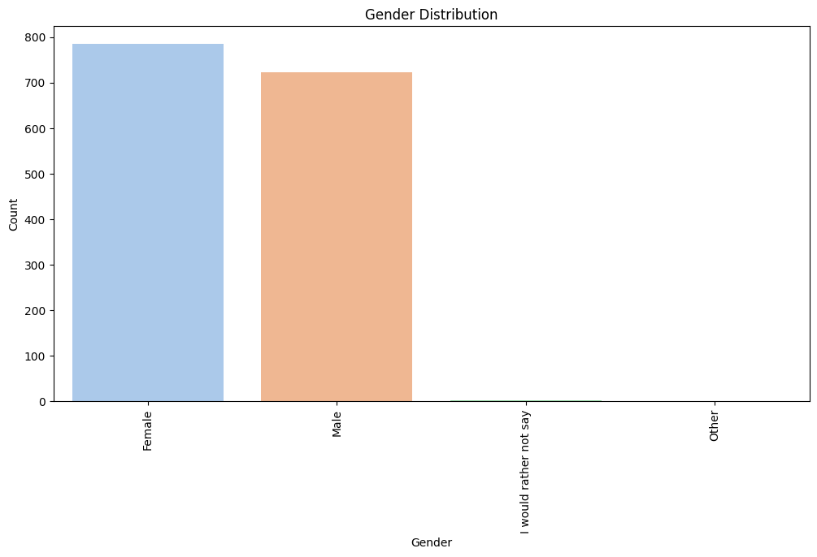

```python
# Features of the Participants
plt.figure(figsize=(12, 6))
sns.countplot(data=employee, x='Gender', order=employee['Gender'].value_counts().index, palette='pastel')
plt.title("Gender Distribution")
plt.xlabel("Gender")
plt.ylabel("Count")
plt.xticks(rotation=90)
plt.show()
```

```python
make_table_for(employee['Gender'])
```

| col_0 Gender | Percentage |
| --- | --- |
| Female | 51.92% |
| Male | 47.82% |
| I would rather not say | 0.20% |
| Other | 0.07% |

Observation: We can conclude that the ratio of Male and Female Participants are almost equal.

## Age

We can visualize the Age of the participants with a Histogram. For detailed analysis I used this visualization to observe incase there is any imbalance in age distribution in participants between Employee and Managerial posts.

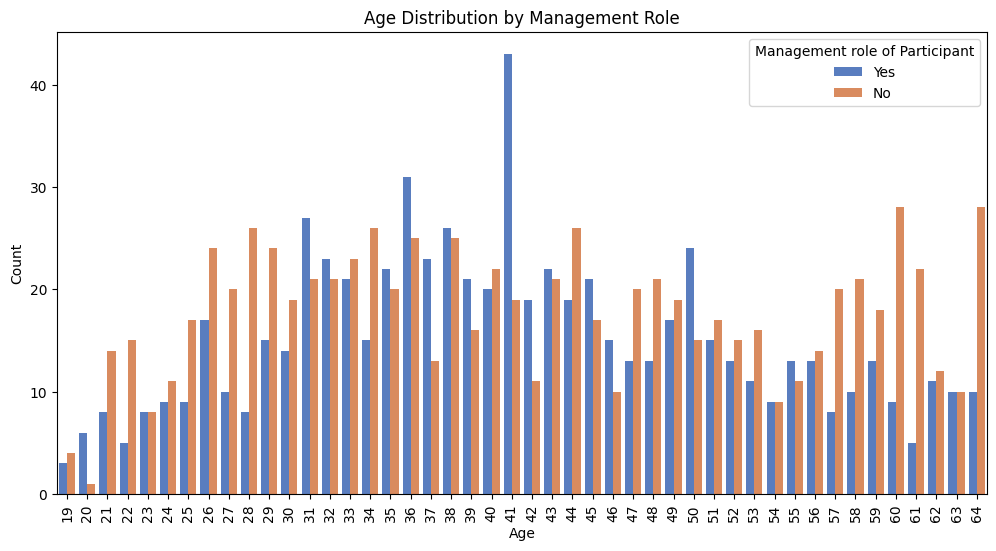

```python
plt.figure(figsize=(12, 6))
sns.countplot(data=employee, x='Age', hue='Management role of Participant', palette='muted')
plt.title("Age Distribution by Management Role")
plt.xlabel("Age")
plt.ylabel("Count")
plt.xticks(rotation=90)
plt.show()
```

```python
employee['Age'].mean()
```

```
41.773809523809526
```

Observation: Average age of the participants are 41-42 years, The age distribution seems well balanced as if the participant being Manager or not.

## Size of Household

The Size of Household implies that how many family members live in the household. We can visualize the Size of Family from a histogram for Metro and Regional dwellers.

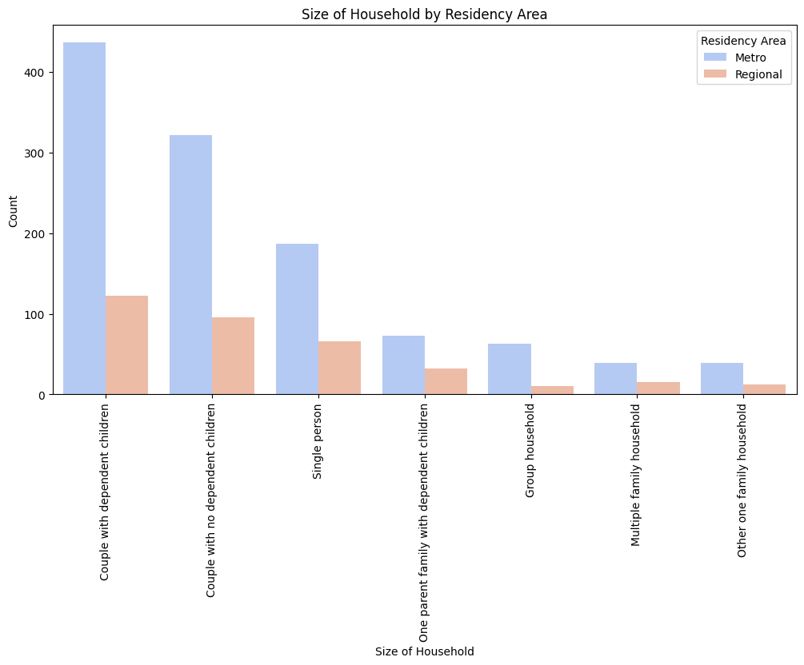

```python
plt.figure(figsize=(12, 6))
sns.countplot(data=employee, x='Size of Household', hue='Residency Area', order=employee['Size of Household'].value_counts().index, palette='coolwarm')
plt.title("Size of Household by Residency Area")
plt.xlabel("Size of Household")
plt.ylabel("Count")
plt.xticks(rotation=90)
plt.show()
```

```python
make_table_for(employee['Size of Household'])
```

| col_0 Size of Household | Percentage |
| --- | --- |
| Couple with dependent children | 36.90% |
| Couple with no dependent children | 27.65% |
| Single person | 16.73% |
| One parent family with dependent children | 6.94% |
| Group household | 4.83% |
| Multiple family household | 3.57% |
| Other one family household | 3.37% |

```python
make_table_for(employee['Residency Area'])
```

| col_0 Residency Area | Percentage |
| --- | --- |
| Metro | 76.65% |
| Regional | 23.35% |

Observation: From the interpretation above, we can see that majority participants are Couple with dependent children and 76% the participants live in Metro area.

# **2.Professional Features of the Participants:**

## Industry

To find out the Industry where most of the participants work, I represented the data with a bar chart and a table containing the percentage distribution.

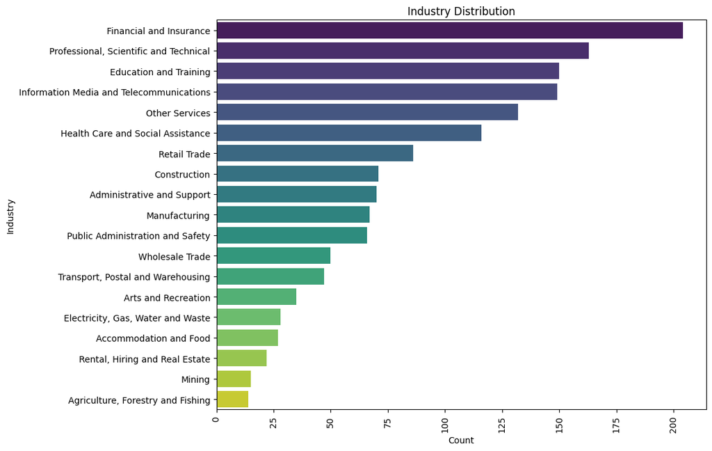

```python
plt.figure(figsize=(10, 8))
sns.countplot(data=employee, y='Industry', order=employee['Industry'].value_counts().index, palette='viridis')
plt.title("Industry Distribution")
plt.ylabel("Industry")
plt.xlabel("Count")
plt.xticks(rotation=90)
plt.show()
```

```python
make_table_for(employee['Industry']).head(10)
```

| col_0 Industry | Percentage |
| --- | --- |
| Financial and Insurance | 13.49% |
| Professional, Scientific and Technical | 10.78% |
| Education and Training | 9.92% |
| Information Media and Telecommunications | 9.85% |
| Other Services | 8.73% |
| Health Care and Social Assistance | 7.67% |
| Retail Trade | 5.69% |
| Construction | 4.70% |
| Administrative and Support | 4.63% |
| Manufacturing | 4.43% |

Observation: From the results shown above, we see that most of the participants work in the Financial and Insurance industry. The next highest occurances are the 'Professional, Scientific and Technical', 'Education and Training' and 'Information Media and Telecommunications'. To be noticed, all of these professions doesn't require much of physical activeness and can be done in a Remote setup with the help of Computers.

## Occupation

A sorted Barchart and a frequency percentage distribution can represent the Occupation of the participants.

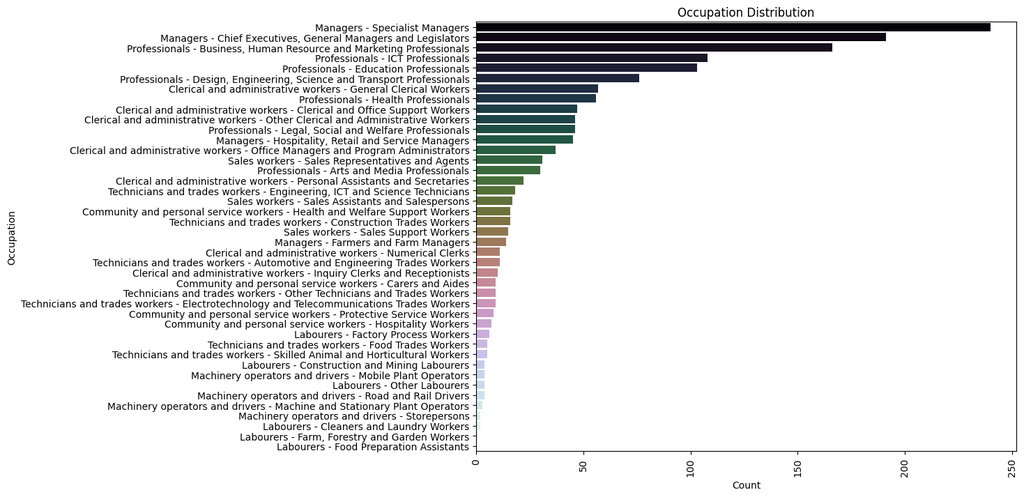

```python
plt.figure(figsize=(10, 8))
sns.countplot(data=employee, y='Occupation', order=employee['Occupation'].value_counts().index, palette='cubehelix')
plt.title("Occupation Distribution")
plt.ylabel("Occupation")
plt.xlabel("Count")
plt.xticks(rotation=90)
plt.show()
```

```python
make_table_for(employee['Occupation']).head(20)
```

| col_0 Occupation | Percentage |
| --- | --- |
| Managers - Specialist Managers | 15.87% |
| Managers - Chief Executives, General Managers and Legislators | 12.63% |
| Professionals - Business, Human Resource and Marketing Professionals | 10.98% |
| Professionals - ICT Professionals | 7.14% |
| Professionals - Education Professionals | 6.81% |
| Professionals - Design, Engineering, Science and Transport Professionals | 5.03% |
| Clerical and administrative workers - General Clerical Workers | 3.77% |
| Professionals - Health Professionals | 3.70% |
| Clerical and administrative workers - Clerical and Office Support Workers | 3.11% |
| Professionals - Legal, Social and Welfare Professionals | 3.04% |
| Clerical and administrative workers - Other Clerical and Administrative Workers | 3.04% |
| Managers - Hospitality, Retail and Service Managers | 2.98% |
| Clerical and administrative workers - Office Managers and Program Administrators | 2.45% |
| Sales workers - Sales Representatives and Agents | 2.05% |
| Professionals - Arts and Media Professionals | 1.98% |
| Clerical and administrative workers - Personal Assistants and Secretaries | 1.46% |
| Technicians and trades workers - Engineering, ICT and Science Technicians | 1.19% |
| Sales workers - Sales Assistants and Salespersons | 1.12% |
| Technicians and trades workers - Construction Trades Workers | 1.06% |
| Community and personal service workers - Health and Welfare Support Workers | 1.06% |

## Participants in Management Positions

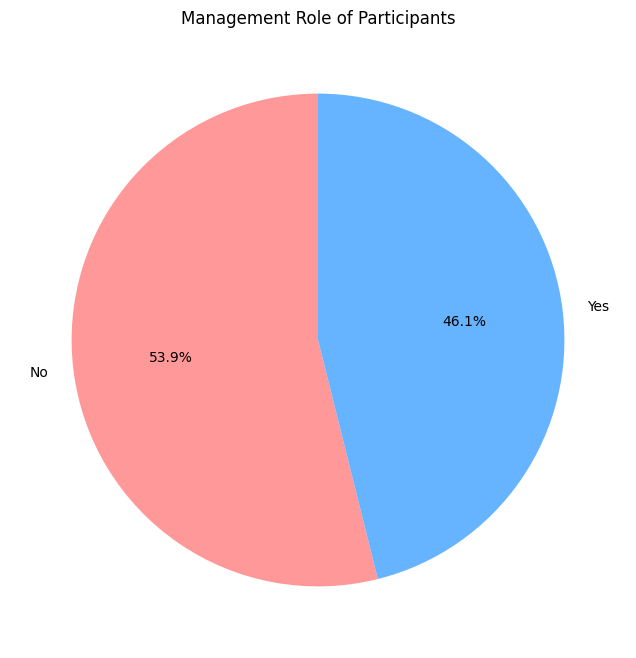

```python
plt.figure(figsize=(8, 8))
employee['Management role of Participant'].value_counts().plot.pie(autopct='%1.1f%%', colors=['#ff9999','#66b3ff'], startangle=90)
plt.title("Management Role of Participants")
plt.ylabel("")
plt.show()
```

```python
make_table_for(employee['Management role of Participant'])
```

| col_0 Management role of Participant | Percentage |
| --- | --- |
| No | 53.90% |
| Yes | 46.10% |

## Employment Duration

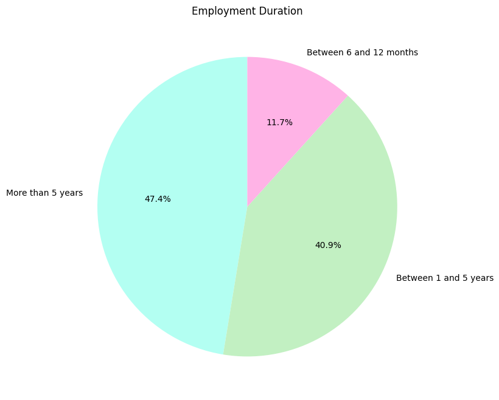

```python
plt.figure(figsize=(8, 8))
employee['Employment Duration'].value_counts().plot.pie(autopct='%1.1f%%', colors=['#b3fff2','#c2f0c2','#ffb3e6'], startangle=90)
plt.title("Employment Duration")
plt.ylabel("")
plt.show()
```

```python
make_table_for(employee['Employment Duration'])
```

| col_0 Employment Duration | Percentage |
| --- | --- |
| More than 5 years | 47.42% |
| Between 1 and 5 years | 40.87% |
| Between 6 and 12 months | 11.71% |

Observation: We see that nearly 87% of the employees are experinced working more than 1 years at 2021.

# 3.Participant's Response on Remote, Onsite and Hybrid:

## Employer's Policy change on Remote after COVID:

In this part, the participants were asked whether their employers changed their working environment into remote afte COVID.

```python
make_table_for(employee["Employer's Policy change on Remote Work"]) # Caution on the apostrophe, use double quote
```

| col_0 Employer's Policy change on Remote Work | Percentage |
| --- | --- |
| Yes | 72.95% |
| No | 27.05% |

Observation: We see that nearly 72% employers switched to remote environment after Covid started.

## Atleast 1 day Hybrid Experince last 6 months-

In this question, the participants were asked whether they had any experince working atleast 1 day working in office, and remote.

```python
make_table_for(employee["1 day Hybrid last 6 months"])
```

| col_0 1 day Hybrid last 6 months | Percentage |
| --- | --- |
| Yes | 60.91% |
| No | 39.09% |

Observation: We see that 60% of the participants had experince working in hybrid in last 6 months.

## Time Spent Working Remotely in 2021 vs Preferred Time 2021 vs Preferred Time in Future

For this comparison, I choose barplot to compare the factors.

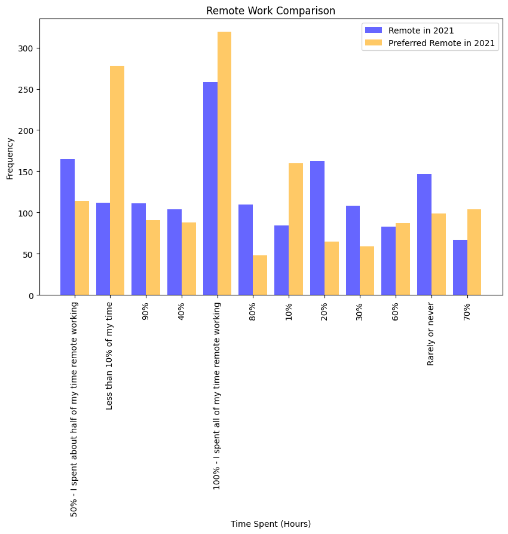

```python
make_clustered_barchart(
    employee["Time Spent Working Remotely in 2021"],
    employee["Preferred Time Spent Working Remotely in 2021"],
    labels=["Remote in 2021", "Preferred Remote in 2021"],
    title="Remote Work Comparison",
    xlabel="Time Spent (Hours)",
    ylabel="Frequency"
)
```

## Duration of Working Hybrid vs Preferred time towards Hybrid:

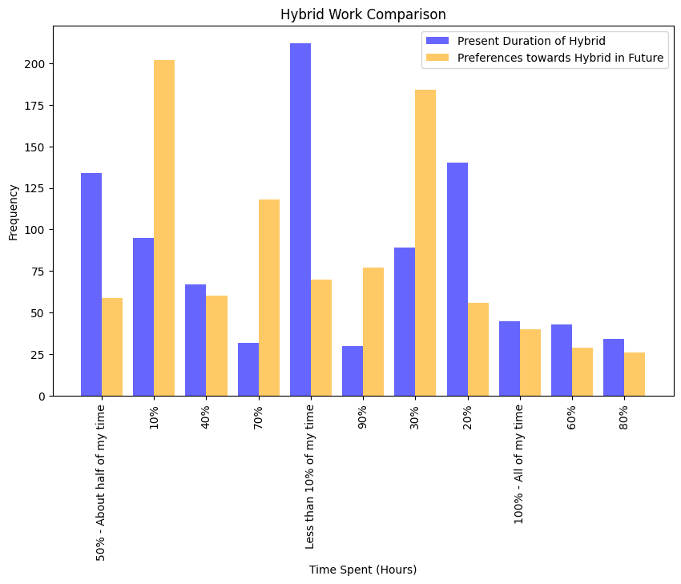

```python
make_clustered_barchart(
    employee["Duration of Hybrid"],
    employee["Preferences towards Hybrid"],
    labels=["Present Duration of Hybrid", "Preferences towards Hybrid in Future"],
    title="Hybrid Work Comparison",
    xlabel="Time Spent (Hours)",
    ylabel="Frequency"
)
```

## Paricipant's Reponses on Some Questions to Understand their Attitude towards Remote Working:

Following are the answers to some questions that the participants were asked to understand their attitude towards Remote Work Environment.

### Employer's Remote Working Policy Suits Him / Her :

```python
make_table_for(employee["Attitude on Employer's Preferences"])
```

| col_0 Attitude on Employer's Preferences | Percentage |
| --- | --- |
| Strongly agree | 34.79% |
| Somewhat agree | 33.66% |
| Neither agree nor disagree | 18.32% |
| Somewhat disagree | 7.47% |
| Strongly disagree | 5.75% |

### Liberty to decide the working time on Remote :

```python
make_table_for(employee["Liberty to make the Choice on Decision"])
```

| col_0 Liberty to make the Choice on Decision | Percentage |
| --- | --- |
| Somewhat agree | 30.49% |
| Strongly agree | 26.39% |
| Neither agree nor disagree | 16.14% |
| Strongly disagree | 13.76% |
| Somewhat disagree | 13.23% |

### Liberty to Choice on Days on Remote :

```python
make_table_for(employee["Liberty to make the Choice on Days"])
```

| col_0 Liberty to make the Choice on Days | Percentage |
| --- | --- |
| Strongly agree | 32.41% |
| Somewhat agree | 31.68% |
| Neither agree nor disagree | 13.76% |
| Strongly disagree | 11.97% |
| Somewhat disagree | 10.19% |

### Direct Manager's role on discretion on Deciding Remote or not :

```python
make_table_for(employee["Direct Manager's role"])
```

| col_0 Direct Manager's role | Percentage |
| --- | --- |
| Somewhat agree | 34.79% |
| Strongly agree | 30.42% |
| Neither agree nor disagree | 18.25% |
| Somewhat disagree | 8.86% |
| Strongly disagree | 7.67% |

### Feeling about your employer’s remote working policy :

```python
make_table_for(employee["Attitude on Employer's Decision on Remote Work"])
```

| col_0 Attitude on Employer's Decision on Remote Work | Percentage |
| --- | --- |
| Strongly Positive | 35.65% |
| Somewhat Positive | 33.86% |
| Neither positive nor negative | 19.64% |
| Somewhat Negative | 7.14% |
| Strongly Negative | 3.70% |

### My Organisation encouraged people to work remotely:

```python
make_table_for(employee["Attitude on Employer's Encouragement"])
```

| col_0 Attitude on Employer's Encouragement | Percentage |
| --- | --- |
| Strongly agree | 31.61% |
| Somewhat agree | 31.15% |
| Neither agree nor disagree | 20.83% |
| Somewhat disagree | 9.19% |
| Strongly disagree | 7.21% |

### Employer's Preparedness for Remote Work Environment:

```python
make_table_for(employee["Attitude on Employer's Preparedness"])
```

| col_0 Attitude on Employer's Preparedness | Percentage |
| --- | --- |
| Somewhat agree | 37.43% |
| Strongly agree | 31.68% |
| Neither agree nor disagree | 16.01% |
| Somewhat disagree | 9.59% |
| Strongly disagree | 5.29% |

### Other people in my organisation to work remotely:

```python
make_table_for(employee["Attitude of Other Employees "]) # Caution about the space after Employees
```

| col_0 Attitude of Other Employees | Percentage |
| --- | --- |
| Somewhat agree | 36.71% |
| Strongly agree | 30.36% |
| Neither agree nor disagree | 15.54% |
| Somewhat disagree | 10.25% |
| Strongly disagree | 7.14% |

### Ease to get Permission on Remote Work:

```python
make_table_for(employee["Ease to get Permission on Remote Work"])
```

| col_0 Ease to get Permission on Remote Work | Percentage |
| --- | --- |
| Strongly agree | 36.51% |
| Somewhat agree | 32.87% |
| Neither agree nor disagree | 17.86% |
| Somewhat disagree | 7.14% |
| Strongly disagree | 5.62% |

### Ease to Collaborate with Colleagues on Remote Work:

```python
make_table_for(employee["Ease to Collaborate with Colleagues"])
```

| col_0 Ease to Collaborate with Colleagues | Percentage |
| --- | --- |
| Somewhat agree | 39.02% |
| Strongly agree | 30.75% |
| Neither agree nor disagree | 15.94% |
| Somewhat disagree | 10.91% |
| Strongly disagree | 3.37% |

### Effect on Promotion on Remote Work:

```python
make_table_for(employee["Effect of Promotion"])
```

| col_0 Effect of Promotion | Percentage |
| --- | --- |
| Neither agree nor disagree | 33.80% |
| Somewhat disagree | 20.44% |
| Somewhat agree | 18.45% |
| Strongly disagree | 17.46% |
| Strongly agree | 9.85% |

### I take more regular breaks on Remote Work:

```python
make_table_for(employee["Attitude on Taking Breaks"])
```

| col_0 Attitude on Taking Breaks | Percentage |
| --- | --- |
| Somewhat agree | 33.66% |
| Neither agree nor disagree | 22.82% |
| Strongly agree | 18.12% |
| Somewhat disagree | 16.34% |
| Strongly disagree | 9.06% |

### Impact of Remote Work on Employer:

```python
make_table_for(employee["Impact on Employer"])
```

| col_0 Impact on Employer | Percentage |
| --- | --- |
| Somewhat Positive | 38.49% |
| Strongly Positive | 29.43% |
| Neither positive nor negative | 19.71% |
| Somewhat Negative | 9.92% |
| Strongly Negative | 2.45% |

### Most Supportive Person at Workplace on Remote Work:

```python
make_table_for(employee["Most Supportive Person(s) on Remote Work"])
```

| col_0 Most Supportive Person(s) on Remote Work | Percentage |
| --- | --- |
| They are about the same | 58.13% |
| My direct manger(s) | 25.40% |
| Senior leadership | 16.47% |

### My employer would encourage more remote working post COVID:

```python
make_table_for(employee["Expected Employer's Encouragement Post Covid"])
```

| col_0 Expected Employer's Encouragement Post Covid | Percentage |
| --- | --- |
| Neither unlikely or likely | 27.12% |
| Somewhat likely | 24.47% |
| Somewhat unlikely | 18.52% |
| Very likely | 15.81% |
| Very unlikely | 14.09% |

### My employer would make changes to support remote working post COVID:

```python
make_table_for(employee["Expected Employer's Support Post Covid"])
```

| col_0 Expected Employer's Support Post Covid | Percentage |
| --- | --- |
| Somewhat likely | 31.68% |
| Neither unlikely or likely | 28.04% |
| Very likely | 16.53% |
| Somewhat unlikely | 12.10% |
| Very unlikely | 11.64% |

### I would have more choice about whether I work remotely:

```python
make_table_for(employee["Attitude on Choice on Remote Post Covid"])
```

| col_0 Attitude on Choice on Remote Post Covid | Percentage |
| --- | --- |
| Somewhat likely | 30.09% |
| Neither unlikely or likely | 25.40% |
| Very likely | 16.80% |
| Somewhat unlikely | 14.68% |
| Very unlikely | 13.03% |

Observation: From the comparison tables we can see above, we find that-

- Participants 'Strongly Agree' with the Remote working environment suits them well, they had the liberty to make choice of the working days, the employers were very positive and encouraging about remote working after COVID.
- However, they don't have any strong opinion on promotion or unsure about employer's attitude to encourage remote working in future/ post COVID.

## Agreeing a Pay Cut in return of Option to work remotely:

The partipants were asked whether they agree on a pay cut in return to let them work remotely.

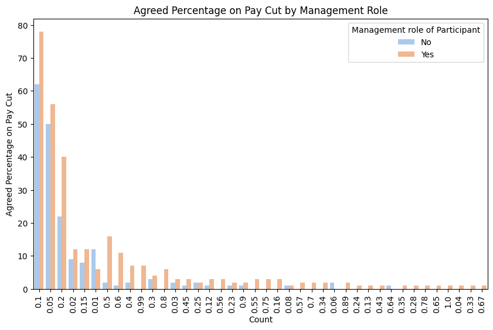

```python
plt.figure(figsize=(10, 6))  # Adjust figure size as needed
sns.countplot(data=employee, x='Agreed percentage on Pay cut', hue='Management role of Participant', order=employee['Agreed percentage on Pay cut'].value_counts().index, palette='pastel')
plt.title('Agreed Percentage on Pay Cut by Management Role')
plt.xlabel('Count')
plt.ylabel('Agreed Percentage on Pay Cut')
plt.xticks(rotation='vertical')  # Rotate x-axis labels vertically
plt.show()
```

```python
make_table_for(employee["Attitude on pay cut"])
```

| col_0 Attitude on pay cut | Percentage |
| --- | --- |
| No | 67.92% |
| Yes | 32.08% |

# **4.Expectations on Time Management in a day in Remote vs Onsite Scenarios:**

In this phase of the survey, the participants were asked about their intended daily distribution of time in Remote and Onsite environment. This will help to get an idea how they intend to balance their personal and professional life.

## Intended Hours to Spend Preparing for work and commuting:

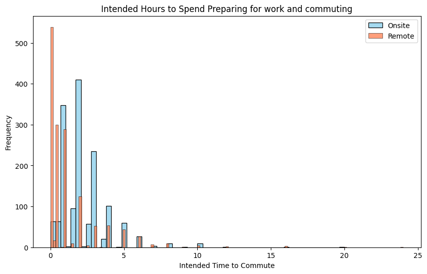

```python
plt.figure(figsize=(10, 6))

sns.histplot(data=employee, x="Intended Time to Commute Onsite", label="Onsite", color="skyblue", alpha=0.75)  # Changed color to skyblue
sns.histplot(data=employee, x="Intended Time to Commute Remote", label="Remote", color="coral", alpha=0.75)    # Changed color to coral

plt.title("Intended Hours to Spend Preparing for work and commuting")
plt.xlabel("Intended Time to Commute")
plt.ylabel("Frequency")
plt.legend()
plt.show()
```

## Intended Hours to Spend Working:

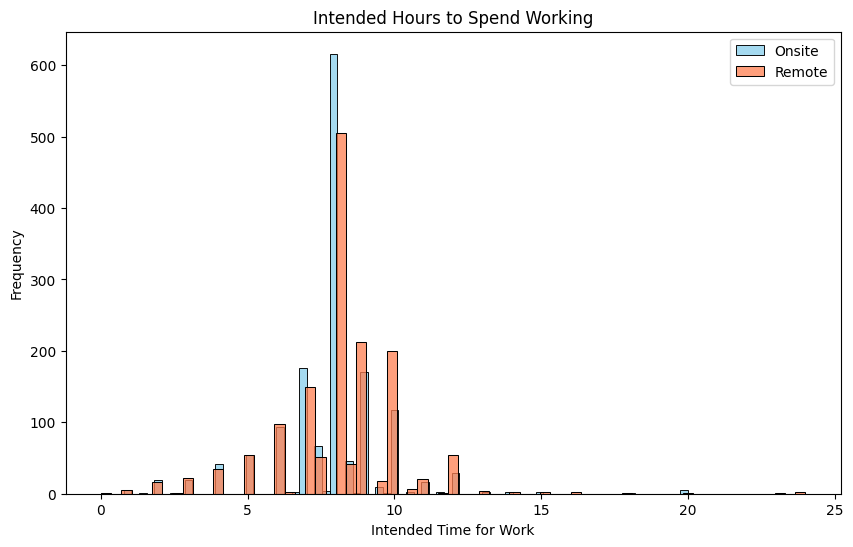

```python
plt.figure(figsize=(10, 6))  # Adjust figure size as needed

# Create the histogram with hue for grouping and specified opacity
sns.histplot(data=employee, x="Intended Time for Work Onsite", label="Onsite", color="skyblue", alpha=0.75)
sns.histplot(data=employee, x="Intended Time for Work Remote", label="Remote", color="coral", alpha=0.75)

plt.title("Intended Hours to Spend Working")
plt.xlabel("Intended Time for Work")
plt.ylabel("Frequency")
plt.legend()
plt.show()
```

## Intended Hours to Spend For Chores:

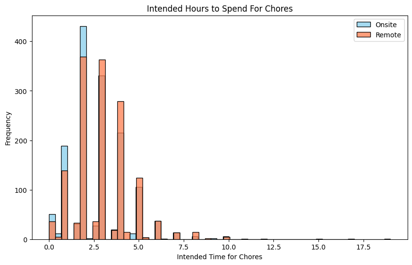

```python
plt.figure(figsize=(10, 6))  # Adjust figure size as needed

# Create the histogram with hue for grouping and specified colors and opacity
sns.histplot(data=employee, x="Intended Time for Chores Onsite", label="Onsite", color="skyblue", alpha=0.75)  # Changed color to skyblue
sns.histplot(data=employee, x="Intended Time for Chores Remote", label="Remote", color="coral", alpha=0.75)    # Changed color to coral

plt.title("Intended Hours to Spend For Chores")
plt.xlabel("Intended Time for Chores")
plt.ylabel("Frequency")
plt.legend()
plt.show()
```

## Intended Hours to Spend For Personal Life:

```python
fig_personal = go.Figure()
fig_personal.add_trace(go.Histogram(name="Onsite",x= employee["Intended Time for Personal Life Onsite"]))
fig_personal.add_trace(go.Histogram(name="Remote",x= employee["Intended Time for Personal Life Remote"]))
fig_personal.update_layout(barmode='group')
fig_personal.update_traces(opacity=0.75,showlegend = True)
fig_personal.show()
```

[output not shown]

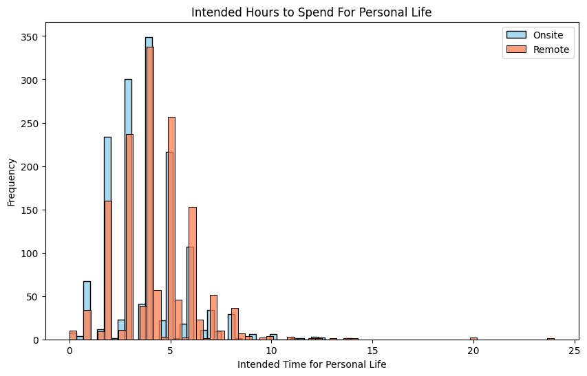

```python
plt.figure(figsize=(10, 6))  # Adjust figure size as needed

# Create the histogram with hue for grouping and specified colors and opacity
sns.histplot(data=employee, x="Intended Time for Personal Life Onsite", label="Onsite", color="skyblue", alpha=0.75)
sns.histplot(data=employee, x="Intended Time for Personal Life Remote", label="Remote", color="coral", alpha=0.75)

plt.title("Intended Hours to Spend For Personal Life")
plt.xlabel("Intended Time for Personal Life")
plt.ylabel("Frequency")
plt.legend()
plt.show()
```

## Intended Hours to Spend to Sleep:

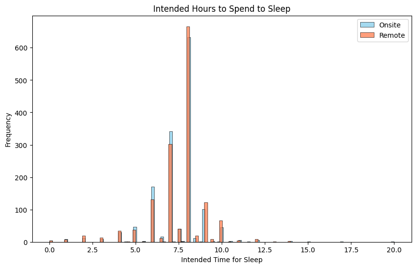

```python
plt.figure(figsize=(10, 6))  # Adjust figure size as needed

# Create the histogram with hue for grouping and specified colors and opacity
sns.histplot(data=employee, x="Intended Time for Sleep Onsite", label="Onsite", color="skyblue", alpha=0.75)
sns.histplot(data=employee, x="Intended Time for Sleep Remote", label="Remote", color="coral", alpha=0.75)

plt.title("Intended Hours to Spend to Sleep")
plt.xlabel("Intended Time for Sleep")
plt.ylabel("Frequency")
plt.legend()
plt.show()
```

Observation: From the charts above, we see that the most evident difference in opinion while remote vs onsite is- to get prepared and commute for work. The participants have no tendency to compromise their working hours or sleep hours whether it is remote or onsite. They prefer more time to spend for personal life and daily chores.

# 5.Barriers working on Remote Environment:

In this segment, we will try to find out the factors that are considered as 'Barriers' for working remotely.

## Barriers that were present in 2020 Data:

Here, for comparison with the 2020 survey data, we are analyzing the factors that were present as biggest barrier and smallest barrier while working remote.

```python
biggest_barrier = barrier.filter(like='biggest', axis=1).stack().reset_index().dropna()
biggest_barrier = biggest_barrier.drop(biggest_barrier.columns[[0,1]], axis=1)

bb = pd.DataFrame(np.array(np.unique(biggest_barrier, return_counts = True)).T, \
                  columns = ['Top Reasons as','Biggest Barriers'])
bb = bb.sort_values(by=['Biggest Barriers'], ascending=False).reset_index(drop=True)

smallest_barrier = barrier.filter(like='smallest', axis=1).stack().reset_index().dropna()
smallest_barrier = smallest_barrier.drop(smallest_barrier.columns[[0,1]], axis=1)

sb = pd.DataFrame(np.array(np.unique(smallest_barrier, return_counts = True)).T,\
                  columns = ['Top Reasons as','Smallest Barriers'])
sb = sb.sort_values(by=['Smallest Barriers'], ascending=False).reset_index(drop=True)

pd.concat([d.reset_index(drop=True) for d in [bb, sb]], axis=1)
```

|  | Top Reasons as | Biggest Barriers | Top Reasons as | Smallest Barriers |
| --- | --- | --- | --- | --- |
| 0 | Difficulty collaborating with remote colleagues | 2113 | Noisy work environment | 1886 |
| 1 | Interruptions | 2036 | Connectivity/internet issues | 1863 |
| 2 | Noisy work environment | 1662 | Lack of privacy | 1640 |
| 3 | Connectivity/internet issues | 1609 | Interruptions | 1607 |
| 4 | Problems with audio-visual setup | 1508 | Lack of appropriate work and meeting spaces | 1581 |
| 5 | Lack of appropriate work and meeting spaces | 1387 | Problems with audio-visual setup | 1422 |
| 6 | Difficulty innovating | 1294 | Difficulty innovating | 1397 |
| 7 | Lack of privacy | 935 | Difficulty collaborating with remote colleagues | 1148 |

## Comparing the change in the Barriers in 2021:

The participants were asked about the change in barrier conditions in 2021.

### Barrier of Caring Responsibilities

```python
make_table_for(employee["Barrier of Caring Responsibilities"])
```

| col_0 Barrier of Caring Responsibilities | Percentage |
| --- | --- |
| Stayed about the same | 36.11% |
| Not a barrier for me | 26.72% |
| Somewhat improved | 18.45% |
| Significantly improved | 9.66% |
| Somewhat worsened | 6.88% |
| Significantly worsened | 2.18% |

### Barrier of Connectivity

```python
make_table_for(employee["Barrier of Connectivity"])
```

| col_0 Barrier of Connectivity | Percentage |
| --- | --- |
| Stayed about the same | 39.55% |
| Not a barrier for me | 19.44% |
| Somewhat improved | 19.11% |
| Somewhat worsened | 10.58% |
| Significantly improved | 8.53% |
| Significantly worsened | 2.78% |

### Barrier of Organization's Software System

```python
make_table_for(employee["Barrier from Organizations Software System"])
```

| col_0 Barrier from Organizations Software System | Percentage |
| --- | --- |
| Stayed about the same | 40.54% |
| Somewhat improved | 23.61% |
| Not a barrier for me | 15.48% |
| Significantly improved | 9.26% |
| Somewhat worsened | 8.47% |
| Significantly worsened | 2.65% |

### Barrier on Collaboration

```python
make_table_for(employee["Barrier on Collaboration"])
```

| col_0 Barrier on Collaboration | Percentage |
| --- | --- |
| Stayed about the same | 34.19% |
| Somewhat improved | 23.15% |
| Not a barrier for me | 17.39% |
| Somewhat worsened | 12.50% |
| Significantly improved | 8.00% |
| Significantly worsened | 4.76% |

### Barrier of Poor Management

```python
make_table_for(employee["Barrier of poor management"])
```

| col_0 Barrier of poor management | Percentage |
| --- | --- |
| Stayed about the same | 40.28% |
| Not a barrier for me | 22.22% |
| Somewhat improved | 14.42% |
| Somewhat worsened | 10.32% |
| Significantly improved | 7.54% |
| Significantly worsened | 5.22% |

### Barrier of IT Equipment

```python
make_table_for(employee["Barrier of IT Equipment"])
```

| col_0 Barrier of IT Equipment | Percentage |
| --- | --- |
| Stayed about the same | 41.27% |
| Somewhat improved | 19.58% |
| Not a barrier for me | 15.87% |
| Somewhat worsened | 11.51% |
| Significantly improved | 8.13% |
| Significantly worsened | 3.64% |

### Barrier of Connectivity

```python
make_table_for(employee["Barrier of Connectivity"])
```

| col_0 Barrier of Connectivity | Percentage |
| --- | --- |
| Stayed about the same | 39.55% |
| Not a barrier for me | 19.44% |
| Somewhat improved | 19.11% |
| Somewhat worsened | 10.58% |
| Significantly improved | 8.53% |
| Significantly worsened | 2.78% |

### Barrier of Feeling Isolated

```python
make_table_for(employee["Barrier of Feeling Isolated"])
```

| col_0 Barrier of Feeling Isolated | Percentage |
| --- | --- |
| Stayed about the same | 36.11% |
| Not a barrier for me | 21.43% |
| Somewhat worsened | 17.66% |
| Somewhat improved | 12.30% |
| Significantly worsened | 6.48% |
| Significantly improved | 6.02% |

### Barrier of Extra Cost

```python
make_table_for(employee["Barrier of Extra Cost"])
```

| col_0 Barrier of Extra Cost | Percentage |
| --- | --- |
| Stayed about the same | 35.78% |
| Not a barrier for me | 21.10% |
| Somewhat improved | 18.45% |
| Somewhat worsened | 12.04% |
| Significantly improved | 8.73% |
| Significantly worsened | 3.90% |

### Barrier of Cyber Security

```python
make_table_for(employee["Barrier of Cyber Security"])
```

| col_0 Barrier of Cyber Security | Percentage |
| --- | --- |
| Stayed about the same | 43.72% |
| Not a barrier for me | 21.10% |
| Somewhat improved | 16.53% |
| Somewhat worsened | 8.33% |
| Significantly improved | 7.28% |
| Significantly worsened | 3.04% |

### Barrier of task cannot be done remotely

```python
make_table_for(employee["Barrier of task cannot be done remotely"])
```

| col_0 Barrier of task cannot be done remotely | Percentage |
| --- | --- |
| Stayed about the same | 39.68% |
| Not a barrier for me | 24.93% |
| Somewhat improved | 15.48% |
| Somewhat worsened | 9.46% |
| Significantly improved | 5.56% |
| Significantly worsened | 4.89% |

### Barrier about working Space

```python
make_table_for(employee["Barrier about working Space"])
```

| col_0 Barrier about working Space | Percentage |
| --- | --- |
| Stayed about the same | 38.16% |
| Somewhat improved | 20.77% |
| Not a barrier for me | 17.86% |
| Somewhat worsened | 10.65% |
| Significantly improved | 8.53% |
| Significantly worsened | 4.03% |

### Barrier on Motivation to Work

```python
make_table_for(employee["Barrier on Motivation"])
```

| col_0 Barrier on Motivation | Percentage |
| --- | --- |
| Stayed about the same | 34.26% |
| Somewhat improved | 22.42% |
| Not a barrier for me | 15.54% |
| Somewhat worsened | 15.01% |
| Significantly improved | 8.73% |
| Significantly worsened | 4.03% |

### Barrier on Management encouragement on Remote:

```python
make_table_for(employee["Barrier on Management encouragement on Remote"])
```

| col_0 Barrier on Management encouragement on Remote | Percentage |
| --- | --- |
| Stayed about the same | 32.21% |
| Not a barrier for me | 25.86% |
| Somewhat improved | 17.92% |
| Somewhat worsened | 10.25% |
| Significantly improved | 8.73% |
| Significantly worsened | 5.03% |

### Barrier of Remote Working Skills:

```python
make_table_for(employee["Barrier of Remote Working Skills"])
```

| col_0 Barrier of Remote Working Skills | Percentage |
| --- | --- |
| Stayed about the same | 34.99% |
| Not a barrier for me | 29.96% |
| Somewhat improved | 18.65% |
| Significantly improved | 8.07% |
| Somewhat worsened | 5.62% |
| Significantly worsened | 2.71% |

### Barrier of Health and Safety:

```python
make_table_for(employee["Barrier of Health and Safety"])
```

| col_0 Barrier of Health and Safety | Percentage |
| --- | --- |
| Stayed about the same | 37.24% |
| Somewhat improved | 20.63% |
| Not a barrier for me | 19.91% |
| Significantly improved | 12.24% |
| Somewhat worsened | 7.67% |
| Significantly worsened | 2.31% |

# **6.Participant's Attitude towards Remote Work:**

In this phase, the participants were asked who they feel about remote working environment.

### Positivity Towards Remote Work

```python
make_table_for(employee["Positivity on Remote Work"])
```

| col_0 Positivity on Remote Work | Percentage |
| --- | --- |
| Somewhat agree | 32.74% |
| Neither agree nor disagree | 29.50% |
| Strongly agree | 26.72% |
| Somewhat disagree | 8.07% |
| Strongly disagree | 2.98% |

### Activeness on Remote Working Environment

```python
make_table_for(employee["Activeness on Remote Work"])
```

| col_0 Activeness on Remote Work | Percentage |
| --- | --- |
| Somewhat agree | 32.14% |
| Neither agree nor disagree | 25.40% |
| Strongly agree | 24.80% |
| Somewhat disagree | 12.37% |
| Strongly disagree | 5.29% |

### Attitude Towards Team Members

```python
make_table_for(employee["Attitute towards Team Members"])
```

| col_0 Attitute towards Team Members | Percentage |
| --- | --- |
| Somewhat agree | 35.45% |
| Neither agree nor disagree | 32.94% |
| Strongly agree | 17.72% |
| Somewhat disagree | 8.86% |
| Strongly disagree | 5.03% |

Observation: The participants 'somewhat agree' that they have

- a positive attitude towards remote work,
- they are active in remote environment and
- the team effort is great as anytime in remote environment.

# 7.What Does the Managers think about Remote Working Environment?

From this part, the subsetted dataset for the Managers are considered for analysis. The corresponding analyses are on the participants who worked in a Managerial post.

## How many of the Managers have Remote Employee Working in their team?

```python
figManagers= px.histogram(manager, x='Remote Employees under Manager ', color = 'Remote Employees under Manager ')
figManagers.show()
```

[output not shown]

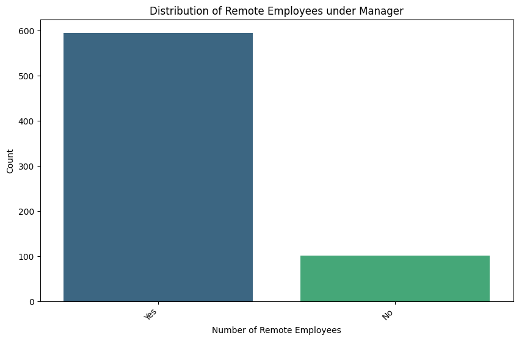

```python
plt.figure(figsize=(10, 6))  # Adjust figure size if needed
sns.countplot(data=manager, x='Remote Employees under Manager ', palette='viridis')
plt.title('Distribution of Remote Employees under Manager')
plt.xlabel('Number of Remote Employees')
plt.ylabel('Count')
plt.xticks(rotation=45, ha='right')  # Rotate x-axis labels for better readability
plt.show()
```

```python
make_table_for(manager["Remote Employees under Manager "]) # Caution about the space after the word Manager
```

| col_0 Remote Employees under Manager | Percentage |
| --- | --- |
| Yes | 85.37% |
| No | 14.63% |

Observation: From the graph and table, we see that 85% of the participants who work for Managerial posts have remote employees under them to manage.

## What was the Manager's opinion on following Questions? -

### I have discretion to offer or deny remote work to employees I manage

```python
make_table_for(manager["Manager's discretion towards Remote "])
```

| col_0 Manager's discretion towards Remote | Percentage |
| --- | --- |
| Somewhat agree | 39.83% |
| Strongly agree | 24.71% |
| Neither agree nor disagree | 19.83% |
| Somewhat disagree | 9.92% |
| Strongly disagree | 5.71% |

### Offering remote work helps me retain employees-

```python
make_table_for(manager["Opinion on Remote Employee Retention"])
```

| col_0 Opinion on Remote Employee Retention | Percentage |
| --- | --- |
| Somewhat agree | 42.86% |
| Strongly agree | 25.55% |
| Neither agree nor disagree | 23.70% |
| Somewhat disagree | 5.21% |
| Strongly disagree | 2.69% |

### Offering remote work helps me to recruit employees

```python
make_table_for(manager["Opinion on Remote Employee Recruitment"])
```

| col_0 Opinion on Remote Employee Recruitment | Percentage |
| --- | --- |
| Somewhat agree | 36.81% |
| Neither agree nor disagree | 32.94% |
| Strongly agree | 22.18% |
| Somewhat disagree | 5.38% |
| Strongly disagree | 2.69% |

### My team works well together when they work remotely

```python
make_table_for(manager["Opinion on Remote Team Work"])
```

| col_0 Opinion on Remote Team Work | Percentage |
| --- | --- |
| Somewhat agree | 46.89% |
| Strongly agree | 26.72% |
| Neither agree nor disagree | 17.14% |
| Somewhat disagree | 7.39% |
| Strongly disagree | 1.85% |

### I find it easy to manage employees remotely (e.g. tasking and monitoring progress)

```python
make_table_for(manager["Opinion on monitoring Remote Team"])
```

| col_0 Opinion on monitoring Remote Team | Percentage |
| --- | --- |
| Somewhat agree | 40.50% |
| Strongly agree | 27.39% |
| Neither agree nor disagree | 17.65% |
| Somewhat disagree | 11.09% |
| Strongly disagree | 3.36% |

### I find it easy to manage poor performers remotely

```python
make_table_for(manager["Opinion on Remote Poor Performers"])
```

| col_0 Opinion on Remote Poor Performers | Percentage |
| --- | --- |
| Somewhat agree | 31.60% |
| Neither agree nor disagree | 26.39% |
| Somewhat disagree | 19.33% |
| Strongly agree | 16.47% |
| Strongly disagree | 6.22% |

### I feel well-prepared to manage employees remotely

```python
make_table_for(manager["Opinion on Preparation for Remote Employee Management"])
```

| col_0 Opinion on Preparation for Remote Employee Management | Percentage |
| --- | --- |
| Somewhat agree | 40.84% |
| Strongly agree | 26.22% |
| Neither agree nor disagree | 23.36% |
| Somewhat disagree | 8.74% |
| Strongly disagree | 0.84% |

### Managing people remotely makes me more focused on results

```python
make_table_for(manager["Opinion on Preparation for Focus on Work"])
```

| col_0 Opinion on Preparation for Focus on Work | Percentage |
| --- | --- |
| Somewhat agree | 43.03% |
| Strongly agree | 25.38% |
| Neither agree nor disagree | 23.19% |
| Somewhat disagree | 7.23% |
| Strongly disagree | 1.18% |

### I find it easy to contact my employees when they work remotely

```python
make_table_for(employee['Opinion on Finding Employees'])
```

| col_0 Opinion on Finding Employees | Percentage |
| --- | --- |
| Somewhat agree | 42.52% |
| Strongly agree | 28.74% |
| Neither agree nor disagree | 16.47% |
| Somewhat disagree | 9.41% |
| Strongly disagree | 2.86% |

### How productive are you, each hour, when you work remotely?

```python
make_table_for(employee["Manager's Productivity on Remote"])
```

| col_0 Manager's Productivity on Remote | Percentage |
| --- | --- |
| My productivity is about same when I work remotely | 21.83% |
| I’m 50% more productive when working remotely (or more) | 18.39% |
| I’m 30% more productive when working remotely | 15.67% |
| I’m 20% more productive when working remotely | 15.15% |
| I’m 10% more productive when working remotely | 7.34% |
| I’m 40% more productive when working remotely | 7.34% |
| I’m 20% less productive when working remotely | 4.89% |
| I’m 10% less productive when working remotely | 4.70% |
| I’m 30% less productive when working remotely | 2.51% |
| I’m 50% less productive when working remotely (or worse) | 1.52% |
| I’m 40% less productive when working remotely | 0.66% |

### How productive are the employees you manage, each hour, when they work remotely?

```python
make_table_for(employee["Employee's Productivity on Remote"])
```

| col_0 Employee's Productivity on Remote | Percentage |
| --- | --- |
| I’m 50% more productive when working remotely (or more) | 17.93% |
| I’m 30% more productive when working remotely | 16.79% |
| I’m 20% more productive when working remotely | 16.36% |
| My productivity is about same when I work remotely | 16.07% |
| I’m 40% more productive when working remotely | 10.47% |
| I’m 10% more productive when working remotely | 9.90% |
| I’m 20% less productive when working remotely | 4.73% |
| I’m 10% less productive when working remotely | 3.87% |
| I’m 30% less productive when working remotely | 2.44% |
| I’m 50% less productive when working remotely (or worse) | 0.86% |
| I’m 40% less productive when working remotely | 0.57% |

Observation: The most interesting part from the analysis on the 'Managers' dataset is that- they agree that their employees are 20% to 50% (highest poll) more productive when they work on remote. They somewhat agree with the questions asked on the rest of the other Managerial challanges that they face on remote work environment.

# Evaluation of the Analysis:

From our analysis we can get into the conclusion as-

### *Impact of COVID pandemic on Remote work:*

The idea of Remote environment was widely welcome by the employers and employees.

### *Expectation post-pandemic:*

The participants prefer full remote or partial remote/hybrid environment post-panedemic.

### *Impact, benefits and positivity towards amount of work on remote:*

The participants are full dedicated to work with professionalism (100% of their working hours) on their working time. Both the managers and employees agree that they are more productive in remote environment.

However, they are unsure how the change in working environment might impact the business decisions and working culture in future. So, they are cautious to think it as a 'practise to go on forever' post COVID.

### *How employees use of time differ when working remotely vs on-site:*

From my observation I found that-

1. Employees tend to be more productive in Remote environment, dedicated 100% of their working time to work.
2. Remote working will save the time and energy spent for getting ready and commuting for work.
3. Remote working creates more opportunity to spend more time for personal life and prioritize factors like daily chores and sleep.